# Employment in hill farming areas

Mike Spencer

3 July 2018

## Introduction

### Purpose

This document is part of a project evaluating the importance of hill farming in Scottish communities. It compares agricultural and population census data at an agricultural parish level to an index of hill farming.

## Population census

Population census data missing for some areas in 2001. Missing for some variables, but not others.

### Population change

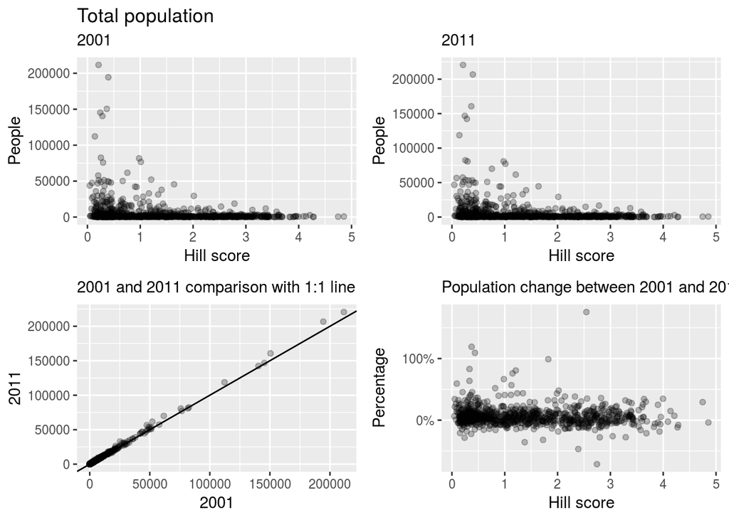

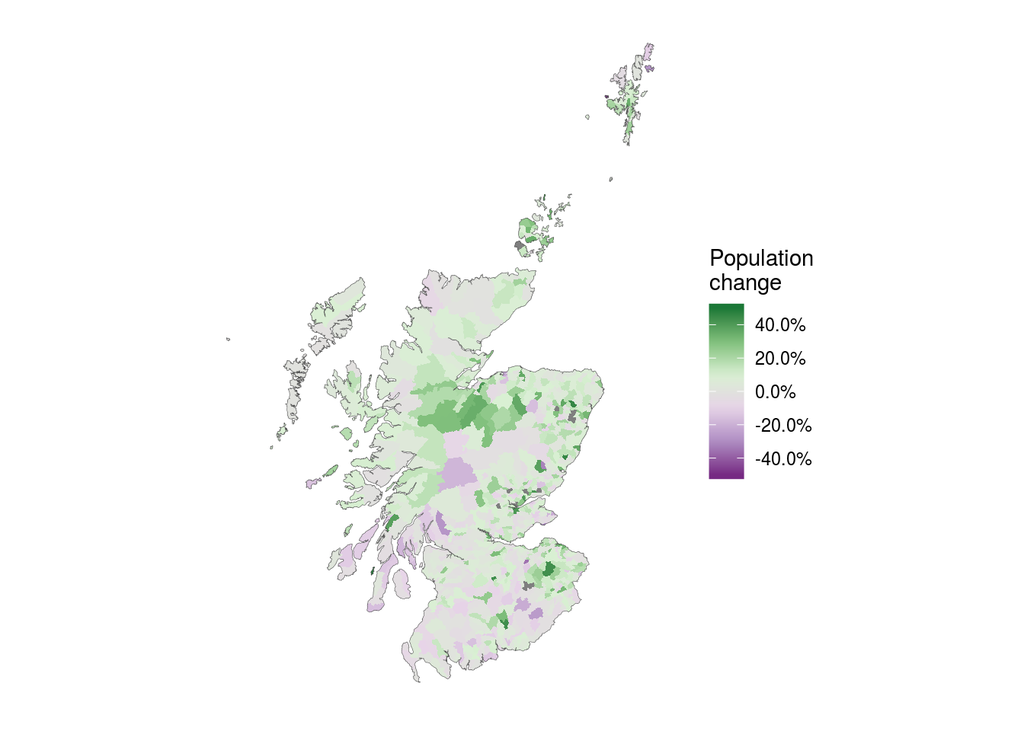

### Population working

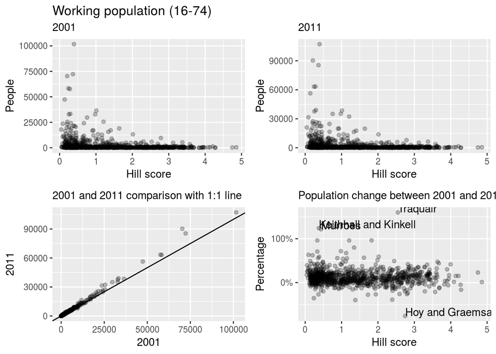

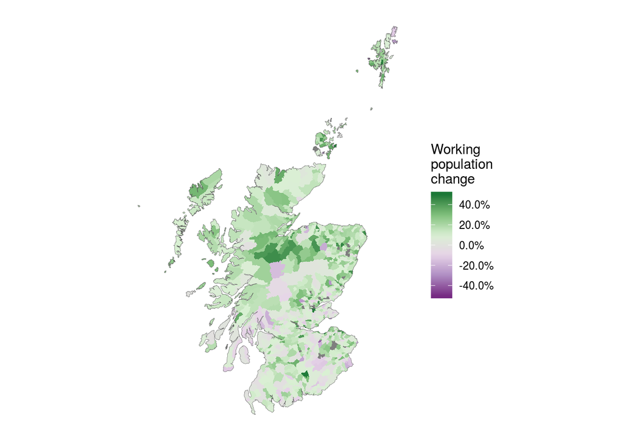

### Public sector type work

Need to detail what’s included in 2001 and 2011 public service, as this could be source of increase!

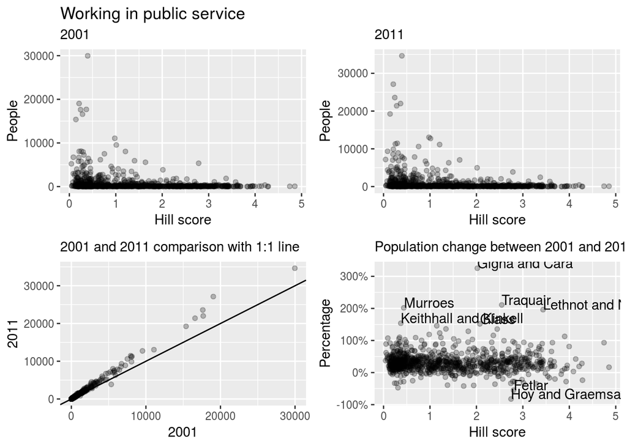

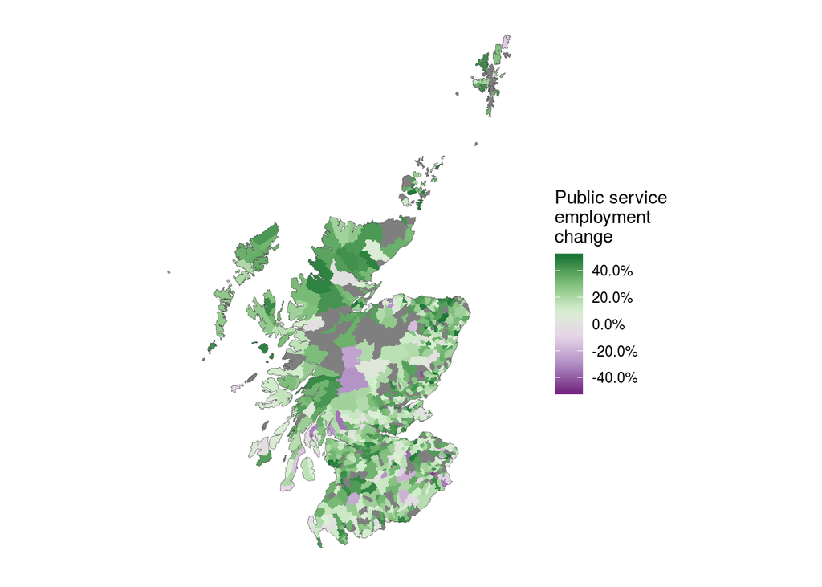

### Primary production

[figure not shown]

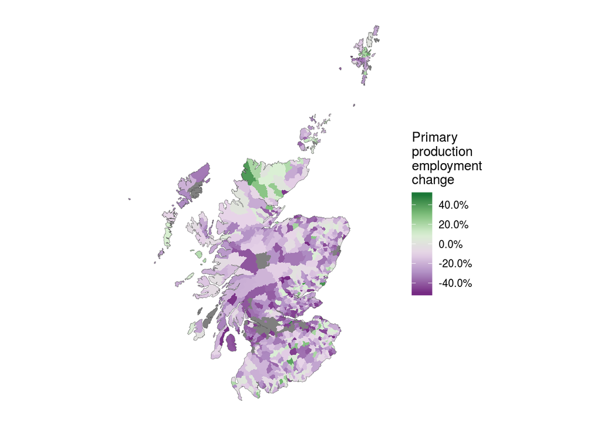

## Agricultural census

Agricultural census questions considered:

- ITEM177 Occupier working full-time on holding
- ITEM178 Occupier working half-time or more on holding
- ITEM179 Occupier working less than half time on holding
- ITEM182 Spouse working full-time on holding
- ITEM183 Spouse working half-time or more on holding
- ITEM184 Spouse working less than half time on holding
- ITEM177 Occupier working full-time on holding
- ITEM178 Occupier working half-time or more on holding
- ITEM179 Occupier working less than half time on holding
- ITEM182 Spouse working full-time on holding
- ITEM183 Spouse working half-time or more on holding
- ITEM184 Spouse working less than half time on holding
- ITEM1714 Full-time regular staff - male - partners
- ITEM1715 Full-time regular staff - male - hired
- ITEM1716 Full-time regular staff - male - member of occupiers family
- ITEM1717 Full-time regular staff - female - partners
- ITEM1718 Part-time regular staff - male - partners
- ITEM1719 Part-time regular staff - female - partners

ITEM 177 is useless - apparently all owner occupiers in 2000 were less than 30 years old.

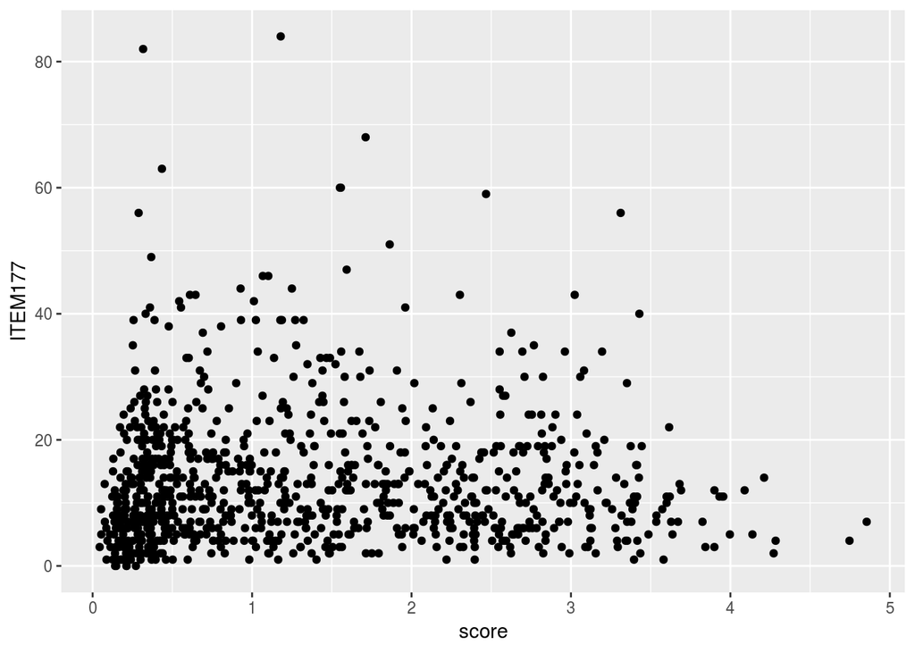

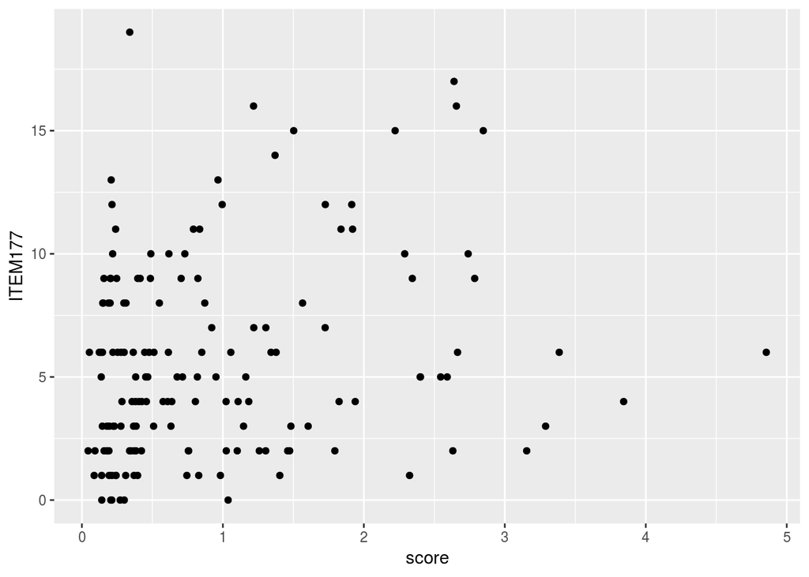

Why so many missing values in 2011 item177?

make up of sector age? gender owned/rented? casual family

Possible to look at productivity change? Is output higher for less staff? Is this universal or do hill areas behave differently?

## Comparisons

- Urban/rural classification: http://www.gov.scot/Publications/2018/03/6040/downloads
- SNH Wild land: https://gateway.snh.gov.uk/natural-spaces/
- SNH National Nature Reserves (NNR): https://gateway.snh.gov.uk/natural-spaces/
- JHI Land capability for forestry: http://www.hutton.ac.uk/learning/natural-resource-datasets

Proportions of each classification against hill score.